# Course Proyect - Practical Machine Learning

Ismael Gómez

24 de diciembre de 2017

### Introduction

It’s the document which to brief the analysis carried out for the Practical machine learning course project. This was done with data from Project [**“Human activity recognition”**](http://web.archive.org/web/20161224072740/http:/groupware.les.inf.puc-rio.br/har), which allows that people both quantify how much of a particular activity they do and quantify how well they do it, recording data about personal activity relatively inexpensively, from devides like accelerometers on the belt, forearm, arm, and dumbell; in this case of 6 participants. More information is available from the website [**here**](http://web.archive.org/web/20161224072740/http:/groupware.les.inf.puc-rio.br/har).

### First step

Due the goal of the project is to predict the “classe” variable in the training set, i first a loaded the “training” and “test” data and confirm that the “test” data only has 20 instances for the final Quiz (without the “classe” variable). Also i found there are a lot of variables (100) with only NA values on test data. So, due after fitting a classification model we need to predict the classes for this test data, i decided not consider this variables (only NA values):

kurtosis_roll_belt, kurtosis_picth_belt, kurtosis_yaw_belt, skewness_roll_belt, skewness_roll_belt.1, skewness_yaw_belt, max_roll_belt, max_picth_belt, max_yaw_belt, min_roll_belt, min_pitch_belt, min_yaw_belt, amplitude_roll_belt, amplitude_pitch_belt, amplitude_yaw_belt, var_total_accel_belt, avg_roll_belt, stddev_roll_belt, var_roll_belt, avg_pitch_belt, stddev_pitch_belt, var_pitch_belt, avg_yaw_belt, stddev_yaw_belt, var_yaw_belt, var_accel_arm, avg_roll_arm, stddev_roll_arm, var_roll_arm, avg_pitch_arm, stddev_pitch_arm, var_pitch_arm, avg_yaw_arm, stddev_yaw_arm, var_yaw_arm, kurtosis_roll_arm, kurtosis_picth_arm, kurtosis_yaw_arm, skewness_roll_arm, skewness_pitch_arm, skewness_yaw_arm, max_roll_arm, max_picth_arm, max_yaw_arm, min_roll_arm, min_pitch_arm, min_yaw_arm, amplitude_roll_arm, amplitude_pitch_arm, amplitude_yaw_arm, kurtosis_roll_dumbbell, kurtosis_picth_dumbbell, kurtosis_yaw_dumbbell, skewness_roll_dumbbell, skewness_pitch_dumbbell, skewness_yaw_dumbbell, max_roll_dumbbell, max_picth_dumbbell, max_yaw_dumbbell, min_roll_dumbbell, min_pitch_dumbbell, min_yaw_dumbbell, amplitude_roll_dumbbell, amplitude_pitch_dumbbell, amplitude_yaw_dumbbell, var_accel_dumbbell, avg_roll_dumbbell, stddev_roll_dumbbell, var_roll_dumbbell, avg_pitch_dumbbell, stddev_pitch_dumbbell, var_pitch_dumbbell, avg_yaw_dumbbell, stddev_yaw_dumbbell, var_yaw_dumbbell, kurtosis_roll_forearm, kurtosis_picth_forearm, kurtosis_yaw_forearm, skewness_roll_forearm, skewness_pitch_forearm, skewness_yaw_forearm, max_roll_forearm, max_picth_forearm, max_yaw_forearm, min_roll_forearm, min_pitch_forearm, min_yaw_forearm, amplitude_roll_forearm, amplitude_pitch_forearm, amplitude_yaw_forearm, var_accel_forearm, avg_roll_forearm, stddev_roll_forearm, var_roll_forearm, avg_pitch_forearm, stddev_pitch_forearm, var_pitch_forearm, avg_yaw_forearm, stddev_yaw_forearm, var_yaw_forearm

For the following analysis i only considered the numeric variables from 8th column forward (8 -> 59). This way now we have a dataset with 19622 rows (instances) and 60 columns.

Finally, i did some base plots with specific variables and classe variable mapped by color, but i couldn’t see a guess about main features or some correlation. I couldn’t use the function “pairs” with all variable at the same time because we have a huge amount of data. Also i plotted a heatmap with all numeric data scaled, in order to see “natural”" clusters in data:

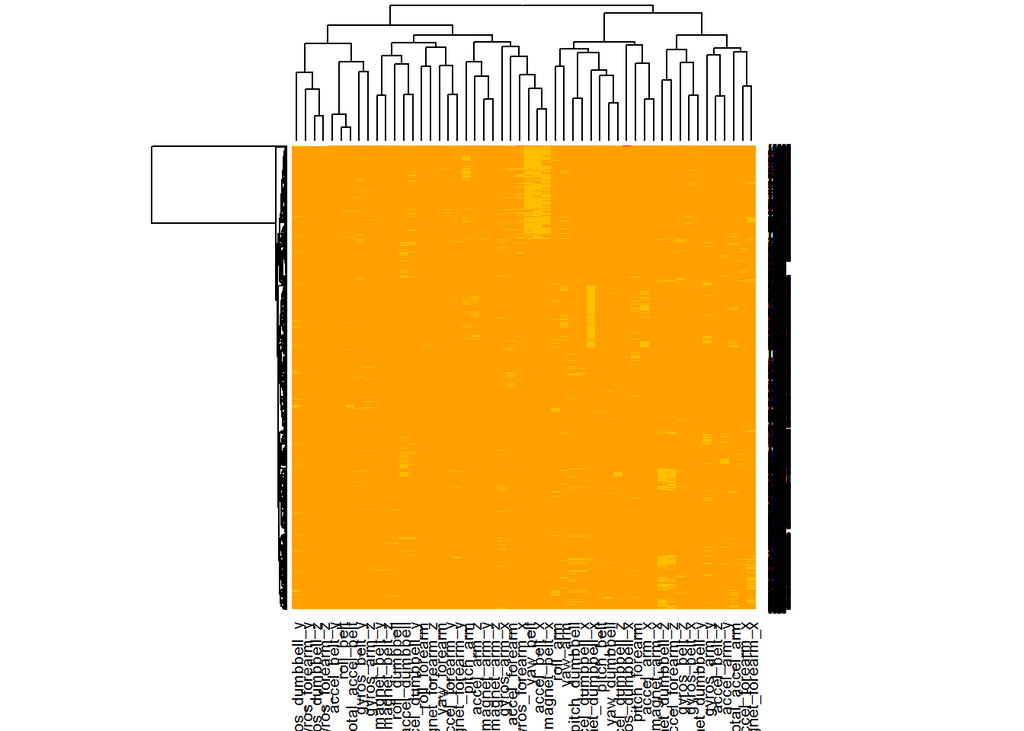

```r
data.scaled <- scale(data2[, 8:59])
data_matrix <- as.matrix(data.scaled)
heatmap(data_matrix, Colv=T, scale='none')
```

## Fitting the model

After loading caret package, i created a data partition with 80% for training dataset and 20% for pretesting dataset. Then a set the seed i tried to fit some models with default configuration:

1. ‘rpart’ with training dataset Accuracy of 51%
2. ‘lda’ with training dataset Accuracy of 70%

I tried with other method but their respective training process late a lot. So after that i play a little time with PCA and Standarization preprocessing, but i couldn’t better fit than before for the same methods.

Also i fit some models with Cross Validation train control (k=10), improving the Accuracy for some models.

```r
library(caret)
set.seed(2017)
inTrain = createDataPartition(data2$classe, p = 8/10)[[1]]
training = data2[ inTrain,]
testing = data2[-inTrain,]

set.seed(2017)
modelFit6 <- train(factor(classe) ~ ., method="treebag", data=training[, 8:60],
                   trControl = trainControl(method='cv'))
modelFit6
```

```
## Bagged CART
##
## 15699 samples
##    52 predictor
##     5 classes: 'A', 'B', 'C', 'D', 'E'
##
## No pre-processing
## Resampling: Cross-Validated (10 fold)
## Summary of sample sizes: 14129, 14127, 14127, 14128, 14129, 14130, ...
## Resampling results:
##
##   Accuracy   Kappa
##   0.9833753  0.9789683
```

```r
set.seed(2017)
predictions <- predict(modelFit6, newdata=testing)
cm <- confusionMatrix(predictions, factor(testing$classe))
cm
```

```
## Confusion Matrix and Statistics
##
##           Reference
## Prediction    A    B    C    D    E
##          A 1108   11    1    2    0
##          B    3  736    4    2    3
##          C    1   12  669   13    2
##          D    2    0    6  623    2
##          E    2    0    4    3  714
##
## Overall Statistics
##
##                Accuracy : 0.9814
##                  95% CI : (0.9767, 0.9854)
##     No Information Rate : 0.2845
##     P-Value [Acc > NIR] : < 2e-16
##
##                   Kappa : 0.9765
##  Mcnemar's Test P-Value : 0.04005
##
## Statistics by Class:
##
##                      Class: A Class: B Class: C Class: D Class: E
## Sensitivity            0.9928   0.9697   0.9781   0.9689   0.9903
## Specificity            0.9950   0.9962   0.9914   0.9970   0.9972
## Pos Pred Value         0.9875   0.9840   0.9598   0.9842   0.9876
## Neg Pred Value         0.9971   0.9928   0.9954   0.9939   0.9978
## Prevalence             0.2845   0.1935   0.1744   0.1639   0.1838
## Detection Rate         0.2824   0.1876   0.1705   0.1588   0.1820
## Detection Prevalence   0.2860   0.1907   0.1777   0.1614   0.1843
## Balanced Accuracy      0.9939   0.9830   0.9847   0.9829   0.9937
```

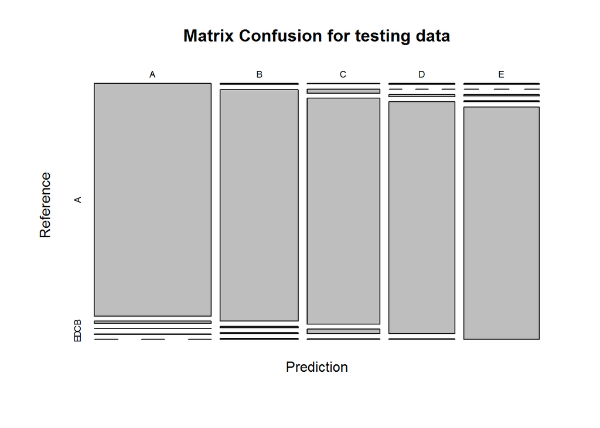

```r
plot(cm$table, main='Matrix Confusion for testing data')
```